# Bayesian modeling illuminates some magnificient details of the `mtcars` dataset, yet, heretofore, fails to dethrone thermodynamics

Jon Nations

2023-02-01

## Background & Motivations

Previous research by Isaac Newton has shown that certain features of cars may have an impact on others. For example, it is hypothesized that the size of the engine (number of cylinders, total displacement of the pistons) may have a strong positive effect on the amount of energy (horsepower) that the car’s engine is capable of generating, but a negative effect on the car’s efficiency (miles per gallon of gasoline). However, the answer to this question remains enigmatic to mammalogists. Additionally, several possible confounds exist, such as the transmission type (automatic or manual).

In this research, I will use the fabled `mtcars` dataset to challenge the laws of thermodynamics by generating predictive models of the relationship between the size of a car’s engine, it’s efficiency, and the power it is capable of generating.

## Intro to the data set

Begin by loading the relevant packages, and using `results='hide'` in the embedded code chunk so the output doesn’t show up in the rendered html file (just saying this for demonstration).

```r
pacman::p_load(tidyverse, kableExtra, GGally, ggdag, dagitty)
```

Here is a scroll-able table of the dataset

|  | mpg | cyl | disp | hp | drat | wt | qsec | vs | am | gear | carb |
| --- | --- | --- | --- | --- | --- | --- | --- | --- | --- | --- | --- |
| Mazda RX4 | 21.0 | 6 | 160.0 | 110 | 3.90 | 2.620 | 16.46 | 0 | 1 | 4 | 4 |
| Mazda RX4 Wag | 21.0 | 6 | 160.0 | 110 | 3.90 | 2.875 | 17.02 | 0 | 1 | 4 | 4 |
| Datsun 710 | 22.8 | 4 | 108.0 | 93 | 3.85 | 2.320 | 18.61 | 1 | 1 | 4 | 1 |
| Hornet 4 Drive | 21.4 | 6 | 258.0 | 110 | 3.08 | 3.215 | 19.44 | 1 | 0 | 3 | 1 |
| Hornet Sportabout | 18.7 | 8 | 360.0 | 175 | 3.15 | 3.440 | 17.02 | 0 | 0 | 3 | 2 |
| Valiant | 18.1 | 6 | 225.0 | 105 | 2.76 | 3.460 | 20.22 | 1 | 0 | 3 | 1 |
| Duster 360 | 14.3 | 8 | 360.0 | 245 | 3.21 | 3.570 | 15.84 | 0 | 0 | 3 | 4 |
| Merc 240D | 24.4 | 4 | 146.7 | 62 | 3.69 | 3.190 | 20.00 | 1 | 0 | 4 | 2 |
| Merc 230 | 22.8 | 4 | 140.8 | 95 | 3.92 | 3.150 | 22.90 | 1 | 0 | 4 | 2 |
| Merc 280 | 19.2 | 6 | 167.6 | 123 | 3.92 | 3.440 | 18.30 | 1 | 0 | 4 | 4 |
| Merc 280C | 17.8 | 6 | 167.6 | 123 | 3.92 | 3.440 | 18.90 | 1 | 0 | 4 | 4 |
| Merc 450SE | 16.4 | 8 | 275.8 | 180 | 3.07 | 4.070 | 17.40 | 0 | 0 | 3 | 3 |
| Merc 450SL | 17.3 | 8 | 275.8 | 180 | 3.07 | 3.730 | 17.60 | 0 | 0 | 3 | 3 |
| Merc 450SLC | 15.2 | 8 | 275.8 | 180 | 3.07 | 3.780 | 18.00 | 0 | 0 | 3 | 3 |
| Cadillac Fleetwood | 10.4 | 8 | 472.0 | 205 | 2.93 | 5.250 | 17.98 | 0 | 0 | 3 | 4 |
| Lincoln Continental | 10.4 | 8 | 460.0 | 215 | 3.00 | 5.424 | 17.82 | 0 | 0 | 3 | 4 |
| Chrysler Imperial | 14.7 | 8 | 440.0 | 230 | 3.23 | 5.345 | 17.42 | 0 | 0 | 3 | 4 |
| Fiat 128 | 32.4 | 4 | 78.7 | 66 | 4.08 | 2.200 | 19.47 | 1 | 1 | 4 | 1 |
| Honda Civic | 30.4 | 4 | 75.7 | 52 | 4.93 | 1.615 | 18.52 | 1 | 1 | 4 | 2 |
| Toyota Corolla | 33.9 | 4 | 71.1 | 65 | 4.22 | 1.835 | 19.90 | 1 | 1 | 4 | 1 |
| Toyota Corona | 21.5 | 4 | 120.1 | 97 | 3.70 | 2.465 | 20.01 | 1 | 0 | 3 | 1 |
| Dodge Challenger | 15.5 | 8 | 318.0 | 150 | 2.76 | 3.520 | 16.87 | 0 | 0 | 3 | 2 |
| AMC Javelin | 15.2 | 8 | 304.0 | 150 | 3.15 | 3.435 | 17.30 | 0 | 0 | 3 | 2 |
| Camaro Z28 | 13.3 | 8 | 350.0 | 245 | 3.73 | 3.840 | 15.41 | 0 | 0 | 3 | 4 |
| Pontiac Firebird | 19.2 | 8 | 400.0 | 175 | 3.08 | 3.845 | 17.05 | 0 | 0 | 3 | 2 |
| Fiat X1-9 | 27.3 | 4 | 79.0 | 66 | 4.08 | 1.935 | 18.90 | 1 | 1 | 4 | 1 |
| Porsche 914-2 | 26.0 | 4 | 120.3 | 91 | 4.43 | 2.140 | 16.70 | 0 | 1 | 5 | 2 |
| Lotus Europa | 30.4 | 4 | 95.1 | 113 | 3.77 | 1.513 | 16.90 | 1 | 1 | 5 | 2 |
| Ford Pantera L | 15.8 | 8 | 351.0 | 264 | 4.22 | 3.170 | 14.50 | 0 | 1 | 5 | 4 |
| Ferrari Dino | 19.7 | 6 | 145.0 | 175 | 3.62 | 2.770 | 15.50 | 0 | 1 | 5 | 6 |
| Maserati Bora | 15.0 | 8 | 301.0 | 335 | 3.54 | 3.570 | 14.60 | 0 | 1 | 5 | 8 |
| Volvo 142E | 21.4 | 4 | 121.0 | 109 | 4.11 | 2.780 | 18.60 | 1 | 1 | 4 | 2 |

Some of these column names may not make sense, so here is a description:

**mpg** = Miles/(US) gallon  
**cyl** = Number of cylinders  
**disp** = Displacement (cu.in.)  
**hp** = Gross horsepower  
**drat** = Rear axle ratio  
**wt** = Weight (lb/1000)  
**qsec** = 1/4 mile time  
**vs** = V/S  
**am** = Transmission (0 = automatic, 1 = manual)  
**gear** = Number of forward gears  
**carb** = Number of carburetors

There are a lot of interesting features here. I believe that the key focus should be variables that indicate the engine size, like `cyl`, and `disp`, variables of efficiency like `mpg`, and indicators of engine performance like `hp`. However, there are some possible confounding features of these cars that might affect the model, such as the weight of the vehicle, and the transmission type.

Lets check some of the correlations between variables, as this may inform us on some of the relationships. However, I am going to drop a few variables to make the plot easier to read. In your report, code like this can be included or hidden from the html, but *do not hide model or data wrangling code!* If you do, no one will know what you did!

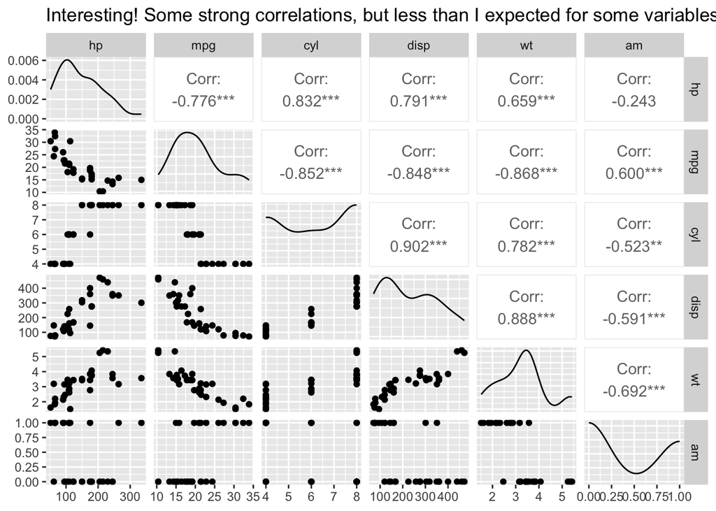

```r
mtcars %>%
  # selecting only the relevant variables
  select(hp, mpg, cyl, disp, wt, am) %>%
  # plotting
  ggpairs() +
  ggtitle("Interesting! Some strong correlations, but less than I expected for some variables")
```

# Scientific Models

#### Model 1

I believe that the size of the engine affects the horsepower, and that horsepower can negatively affect efficiency. But the relationship is complicated

I will write it out here

```r
car_dag <-
  dagitty(
    "dag {
    Mpg <- Hp <- Cyl
    Mpg <- Hp <- Disp
    Mpg <- Disp <- Cyl
    Mpg <- Wt <- Cyl
    Mpg <- Wt <- Disp
    Mpg <- Disp
    Mpg <- Cyl
    }"
  )
```

So there are a lot of moving pieces here! Plotting the DAG

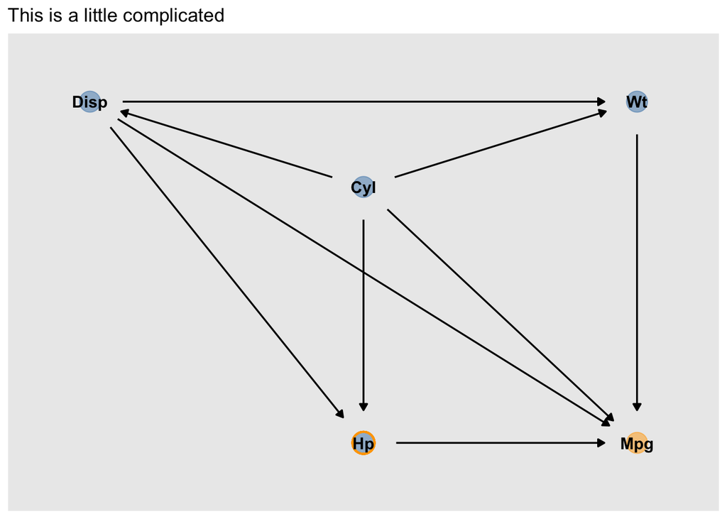

Fortunately, I can use the DAG I drew here to understand which variables to condition on.

```r
adjustmentSets(car_dag, exposure = "Hp", outcome = "Mpg")
```

```
## { Cyl, Disp }
```

So, to modeling the effect of Horsepower on Miles-per-Gallon, I need to stratify on the number of cylinders and the displacement.

Here is the initial model:
$$\begin{align*}
\text{MPG}_i & \sim \operatorname{Normal}(\mu_i, \sigma) \\
\mu_i & = \alpha + \beta_1 \text{Horsepower}_i + \beta_2
\text{Displacement}_i + \beta_3 \text{Cylinders}
\end{align*}$$

#### Model 2

$$\begin{align*}
\text{MPG}_i & \sim \operatorname{Normal}(\mu_i, \sigma) \\
\mu_i & = \alpha + \beta_1 \text{Horsepower}_i + \beta_2
\text{Displacement}_i + \beta_3 \text{Cylinders} + \beta_4
\text{Transmission}
\end{align*}$$

# Modeling

I will be using `brms` to build my models

#### Data Wrangle

We need to center all the variables, and turn the transmission type to factors. It may be a good idea to explore cylinders as ordinal variables or factors, but this is only for illustrative purposes.

```r
scale2 <- function(x, na.rm = TRUE) (x - mean(x, na.rm = na.rm)) / sd(x, na.rm)

mtcars <- mtcars %>%
  select(mpg, disp, hp, wt, cyl, am) %>%
  #scale all cont. varaibles
  mutate_at(vars(1:5), scale2) %>%
  mutate(
    #Now 1 will be automatic transmission, 2 is manual
    am = as.factor(am + 1),
    #cylinder to factor
    #cyl = as.factor(cyl)
    )
```

### Model 1

Load relevant packages

```r
pacman::p_load(brms, cmdstanr)
```

```r
#create formula
formula1 <- brmsformula(mpg ~ 1 + cyl + hp + disp )

#check priors
get_prior(formula = formula1, data = mtcars)
```

```
##                    prior     class coef group resp dpar nlpar lb ub
##                   (flat)         b
##                   (flat)         b  cyl
##                   (flat)         b disp
##                   (flat)         b   hp
##  student_t(3, -0.1, 2.5) Intercept
##     student_t(3, 0, 2.5)     sigma                             0
##        source
##       default
##  (vectorized)
##  (vectorized)
##  (vectorized)
##       default
##       default
```

Now I can make my new prior for prior predictive testing

#### Prior Check

```r
prior1 = c(prior(normal(0, 1), class = b),
                prior(exponential(1), class = sigma))

#NOTE THE SAMPLE_PRIOR = "ONLY"!!
m1_prior <- brm(formula1,
          data = mtcars,
          prior = prior1,
          refresh = 0,
          sample_prior = 'only',
          iter = 2000,
          warmup = 1000,
          chains = 4,
          cores = 4,
          #if you want to save your model so it doesn't run each time, do this
          #file = "ex_mod1_prior",
          backend = 'cmdstanr',
          )
```

Lets check the priors using prior-predictive checks

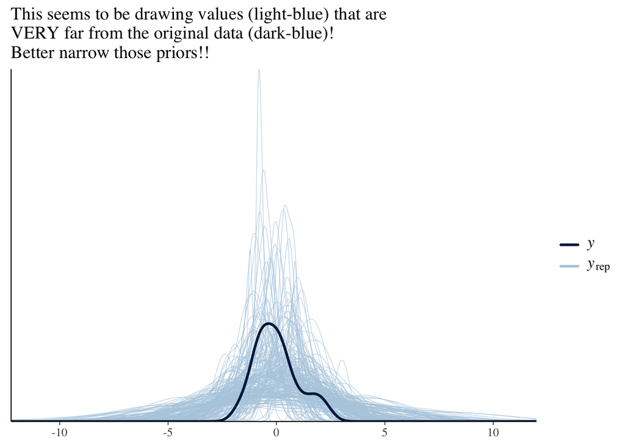

```r
pp_check(m1_prior, ndraws = 200) + ggtitle("This seems to be drawing values (light-blue) that are\nVERY far from the original data (dark-blue)!\nBetter narrow those priors!!")
```

#### Model

```r
prior2 = c(prior(normal(0, 0.3), class = b),
                prior(exponential(4), class = sigma))


m1 <- brm(formula1,
          data = mtcars,
          prior = prior2,
          refresh = 0,
          iter = 2000,
          warmup = 1000,
          chains = 4,
          cores = 4,
          backend = 'cmdstanr',
          file = "ex_mod1")
m1
```

```
##  Family: gaussian
##   Links: mu = identity; sigma = identity
## Formula: mpg ~ 1 + cyl + hp + disp
##    Data: mtcars (Number of observations: 32)
##   Draws: 4 chains, each with iter = 2000; warmup = 1000; thin = 1;
##          total post-warmup draws = 4000
##
## Population-Level Effects:
##           Estimate Est.Error l-95% CI u-95% CI Rhat Bulk_ESS Tail_ESS
## Intercept    -0.00      0.09    -0.18     0.18 1.00     3692     2648
## cyl          -0.34      0.17    -0.68    -0.00 1.00     2904     2324
## hp           -0.20      0.14    -0.47     0.07 1.00     3387     2700
## disp         -0.35      0.16    -0.67    -0.05 1.00     3321     3045
##
## Family Specific Parameters:
##       Estimate Est.Error l-95% CI u-95% CI Rhat Bulk_ESS Tail_ESS
## sigma     0.51      0.07     0.40     0.66 1.00     3095     2154
##
## Draws were sampled using sample(hmc). For each parameter, Bulk_ESS
## and Tail_ESS are effective sample size measures, and Rhat is the potential
## scale reduction factor on split chains (at convergence, Rhat = 1).
```

Everything looks pretty good! Good convergence, no errors, reasonable error on the estimates. Let’s plot just to be sure.

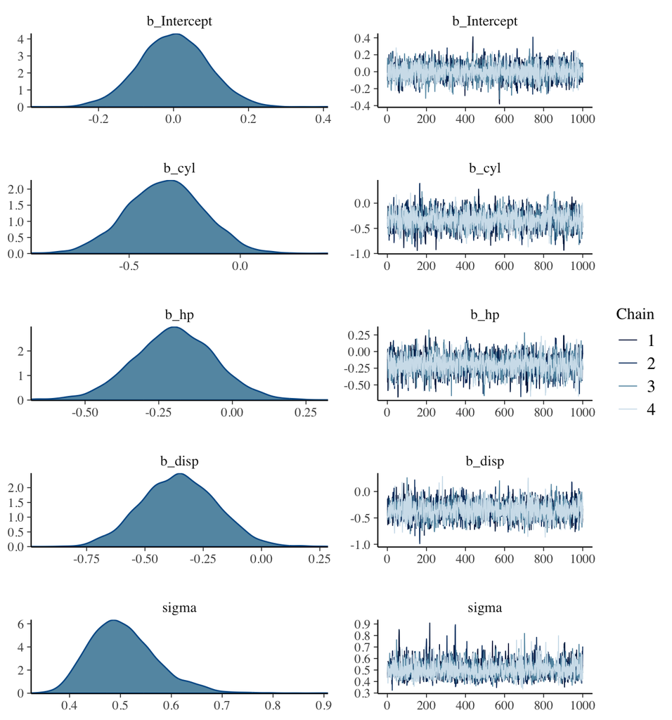

```r
plot(m1, N = 7)
```

These chains look good, as each of the 4 chains has converged on the same region of parameter space.

#### Alternative model without cylinder

There is a pretty strong correlation between the number of cylinders and the displacement. I wonder if this potential multicollinearity affects the outcome?

I will run a model without cylinder

```r
m1.2 <- update(m1, formula. = ~ . - cyl, backend = 'cmdstanr')
m1.2
```

```
##  Family: gaussian
##   Links: mu = identity; sigma = identity
## Formula: mpg ~ hp + disp
##    Data: mtcars (Number of observations: 32)
##   Draws: 4 chains, each with iter = 2000; warmup = 1000; thin = 1;
##          total post-warmup draws = 4000
##
## Population-Level Effects:
##           Estimate Est.Error l-95% CI u-95% CI Rhat Bulk_ESS Tail_ESS
## Intercept    -0.00      0.09    -0.18     0.18 1.00     3435     2311
## hp           -0.31      0.13    -0.57    -0.06 1.00     2210     1984
## disp         -0.54      0.13    -0.80    -0.28 1.00     2210     2054
##
## Family Specific Parameters:
##       Estimate Est.Error l-95% CI u-95% CI Rhat Bulk_ESS Tail_ESS
## sigma     0.52      0.07     0.41     0.67 1.00     3654     2924
##
## Draws were sampled using sample(hmc). For each parameter, Bulk_ESS
## and Tail_ESS are effective sample size measures, and Rhat is the potential
## scale reduction factor on split chains (at convergence, Rhat = 1).
```

Interesting, dropping the number of cylinders pushed the **hp** effect a bit more negative, but the error didn’t change much for either **hp** or **disp**

Use `loo` to tell us if keeping **cyl** in improves predictive accuracy

```r
l1 <- loo(m1, m1.2)
l1$diffs
```

```
##      elpd_diff se_diff
## m1    0.0       0.0
## m1.2 -0.9       1.2
```

Keeping cylinder does improve the prediction, though not in a large way. Since there is a connection between cylinder and displacement, and since there is no negative result from multicollinearity, we will keep it.

#### Posterior Predictive Check

Check the posterior predictive accuracy of the model

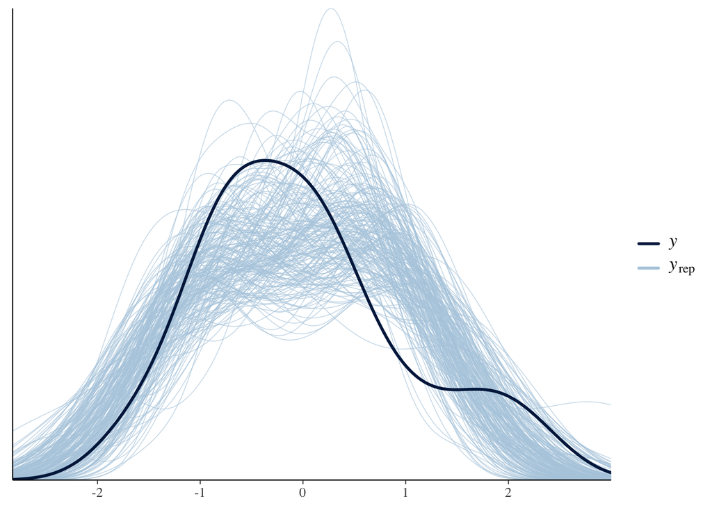

```r
pp_check(m1, ndraws = 200)
```

This seems ok, not great, but there were no divergent transitions, there were no high pareto-$K$ values in the loo analysis, and the shape fits, then I think it is ok to proceed.

#### Results & Plotting

Explore some of the results

```r
pacman::p_load(tidybayes)
```

```r
nd <- tibble(hp = seq(from = -1.5, to = 2.3, length.out = 32),
             cyl = seq(from = -1.5, to = 2.3, length.out = 32),
             disp = seq(from = -1.5, to = 2.3, length.out = 32))
```

Plot the displacement

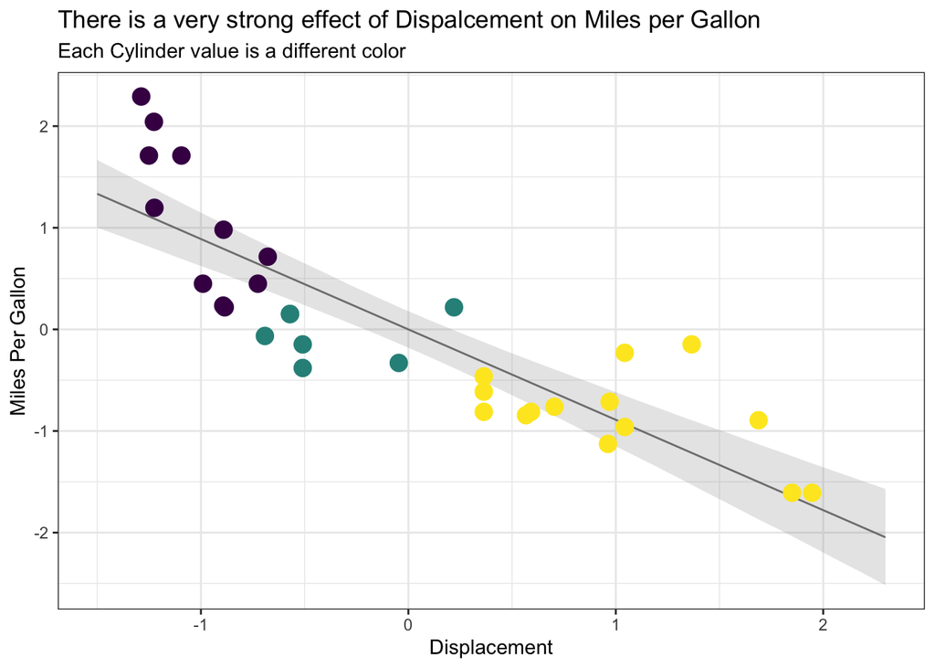

### Model 2

How does transmission impact the effect of engine size and power on efficiency?

```r
#create formula
formula2 <- brmsformula(mpg ~ 0 + cyl + hp + disp + am )

#check priors
get_prior(formula = formula2, data = mtcars)
```

```
##                 prior class coef group resp dpar nlpar lb ub       source
##                (flat)     b                                       default
##                (flat)     b  am1                             (vectorized)
##                (flat)     b  am2                             (vectorized)
##                (flat)     b  cyl                             (vectorized)
##                (flat)     b disp                             (vectorized)
##                (flat)     b   hp                             (vectorized)
##  student_t(3, 0, 2.5) sigma                             0         default
```

#### Prior Check

```r
prior2 = c(prior(normal(0, .25), class = b),
                prior(exponential(4), class = sigma))


m2_prior <- brm(formula2,
          data = mtcars,
          prior = prior2,
          refresh = 0,
          sample_prior = 'only',
          iter = 2000,
          warmup = 1000,
          chains = 4,
          cores = 4,
          #file = "ex_mod2_prior",
          backend = 'cmdstanr'
          )
```

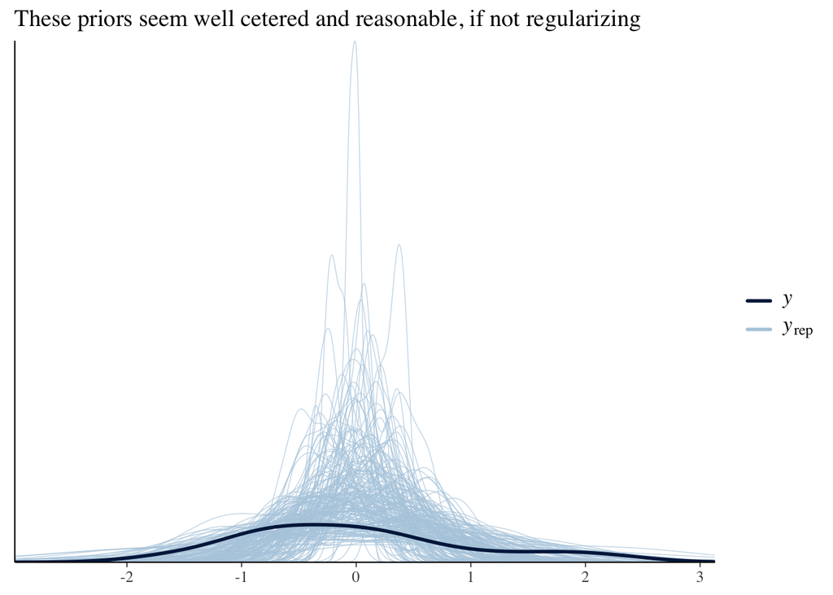

```r
pp_check(m2_prior, ndraws = 200) + ggtitle("These priors seem well cetered and reasonable, if not regularizing")
```

#### Model 2

```r
m2 <- brm(formula2,
          data = mtcars,
          prior = prior2,
          refresh = 0,
          iter = 2000,
          warmup = 1000,
          chains = 4,
          cores = 4,
          #if you want to save your model so it doesn't run each time, do this
          #file = "ex_mod2",
          backend = 'cmdstanr'
          )
m2
```

```
##  Family: gaussian
##   Links: mu = identity; sigma = identity
## Formula: mpg ~ 0 + cyl + hp + disp + am
##    Data: mtcars (Number of observations: 32)
##   Draws: 4 chains, each with iter = 2000; warmup = 1000; thin = 1;
##          total post-warmup draws = 4000
##
## Population-Level Effects:
##      Estimate Est.Error l-95% CI u-95% CI Rhat Bulk_ESS Tail_ESS
## cyl     -0.26      0.15    -0.56     0.02 1.00     3289     2467
## hp      -0.29      0.13    -0.54    -0.03 1.00     3430     2846
## disp    -0.23      0.15    -0.53     0.07 1.00     3027     2809
## am1     -0.18      0.11    -0.39     0.04 1.00     3690     2648
## am2      0.24      0.13    -0.02     0.50 1.00     3383     2870
##
## Family Specific Parameters:
##       Estimate Est.Error l-95% CI u-95% CI Rhat Bulk_ESS Tail_ESS
## sigma     0.47      0.06     0.36     0.61 1.00     3702     2800
##
## Draws were sampled using sample(hmc). For each parameter, Bulk_ESS
## and Tail_ESS are effective sample size measures, and Rhat is the potential
## scale reduction factor on split chains (at convergence, Rhat = 1).
```

The models properly converged, ESS values are high (for 4K iterations), and Rhat values are at 1.

Here we see that the transmission type is important, as manual transmissions have positive values, or high mpg, and automatic transmissions have low values, or low efficiency.

#### Hypothesis testing

Let’s test to see if transmissions truly differ in their mpg ratings.

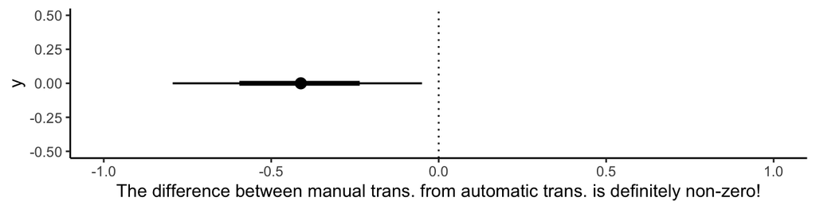

#### Results & Plotting

Plot the effect of horsepower and displacement on efficiency, visualizing the differences in transmission type

[figure not shown]

```r
library(patchwork)
#Patchwork is a wonderful tool for making figures!

p1 <- plot(conditional_effects(m2, effects  = 'disp:am'), plot = F)[[1]] +
  scale_fill_viridis_d(end = 0.7) +
  scale_colour_viridis_d(end = 0.7) +
  theme(legend.position = "none") + theme_bw()
p2 <- plot(conditional_effects(m2, effects  = 'hp:am'), plot = F)[[1]] +
  scale_fill_viridis_d(end = 0.7) +
  scale_colour_viridis_d(end = 0.7) + theme_bw()

(p1 | p2) + plot_layout(guides = "collect")  +
  plot_annotation(title = 'The effect of engine size and power on efficiency varies with transmission type.\nManual transmissions (in green) have higher efficiency.',
    caption = 'Caption here - try changing variable names!')
```

# Interpretation & Discussion